# individual2.Rmd

Sonya Haan

## Lab 5

# Part 1: Accident Data

**Load the data and packages**

```r
acc <- read.csv("https://raw.githubusercontent.com/xdaiISU/ds202materials/master/hwlabs/fars2017/accident.csv", stringsAsFactors = FALSE)
names(acc)
```

```
##  [1] "STATE"      "ST_CASE"    "VE_TOTAL"   "VE_FORMS"   "PVH_INVL"
##  [6] "PEDS"       "PERNOTMVIT" "PERMVIT"    "PERSONS"    "COUNTY"
## [11] "CITY"       "DAY"        "MONTH"      "YEAR"       "DAY_WEEK"
## [16] "HOUR"       "MINUTE"     "NHS"        "RUR_URB"    "FUNC_SYS"
## [21] "RD_OWNER"   "ROUTE"      "TWAY_ID"    "TWAY_ID2"   "MILEPT"
## [26] "LATITUDE"   "LONGITUD"   "SP_JUR"     "HARM_EV"    "MAN_COLL"
## [31] "RELJCT1"    "RELJCT2"    "TYP_INT"    "WRK_ZONE"   "REL_ROAD"
## [36] "LGT_COND"   "WEATHER1"   "WEATHER2"   "WEATHER"    "SCH_BUS"
## [41] "RAIL"       "NOT_HOUR"   "NOT_MIN"    "ARR_HOUR"   "ARR_MIN"
## [46] "HOSP_HR"    "HOSP_MN"    "CF1"        "CF2"        "CF3"
## [51] "FATALS"     "DRUNK_DR"
```

```r
person <- read.csv("https://raw.githubusercontent.com/xdaiISU/ds202materials/master/hwlabs/fars2017/person.csv", stringsAsFactors = FALSE)
names(person)
```

```
##  [1] "STATE"      "ST_CASE"    "VE_FORMS"   "VEH_NO"     "PER_NO"
##  [6] "STR_VEH"    "COUNTY"     "DAY"        "MONTH"      "HOUR"
## [11] "MINUTE"     "RUR_URB"    "FUNC_SYS"   "HARM_EV"    "MAN_COLL"
## [16] "SCH_BUS"    "MAKE"       "MAK_MOD"    "BODY_TYP"   "MOD_YEAR"
## [21] "TOW_VEH"    "SPEC_USE"   "EMER_USE"   "ROLLOVER"   "IMPACT1"
## [26] "FIRE_EXP"   "AGE"        "SEX"        "PER_TYP"    "INJ_SEV"
## [31] "SEAT_POS"   "REST_USE"   "REST_MIS"   "AIR_BAG"    "EJECTION"
## [36] "EJ_PATH"    "EXTRICAT"   "DRINKING"   "ALC_DET"    "ALC_STATUS"
## [41] "ATST_TYP"   "ALC_RES"    "DRUGS"      "DRUG_DET"   "DSTATUS"
## [46] "DRUGTST1"   "DRUGTST2"   "DRUGTST3"   "DRUGRES1"   "DRUGRES2"
## [51] "DRUGRES3"   "HOSPITAL"   "DOA"        "DEATH_DA"   "DEATH_MO"
## [56] "DEATH_YR"   "DEATH_HR"   "DEATH_MN"   "DEATH_TM"   "LAG_HRS"
## [61] "LAG_MINS"   "P_SF1"      "P_SF2"      "P_SF3"      "WORK_INJ"
## [66] "HISPANIC"   "RACE"       "LOCATION"
```

```r
library(ggplot2)
library(tidyverse)
```

**Are there some days of the week where more accidents happen than on others (use variable DAY_WEEK)?**

```r
acc$DAY_WEEK <- factor(acc$DAY_WEEK)
levels(acc$DAY_WEEK) <- c("SUN", "MON", "TUE", "WED", "THU", "FRI", "SAT")
table(acc$DAY_WEEK)
```

```
##
##  SUN  MON  TUE  WED  THU  FRI  SAT
## 5360 4374 4347 4314 4621 5358 5873
```

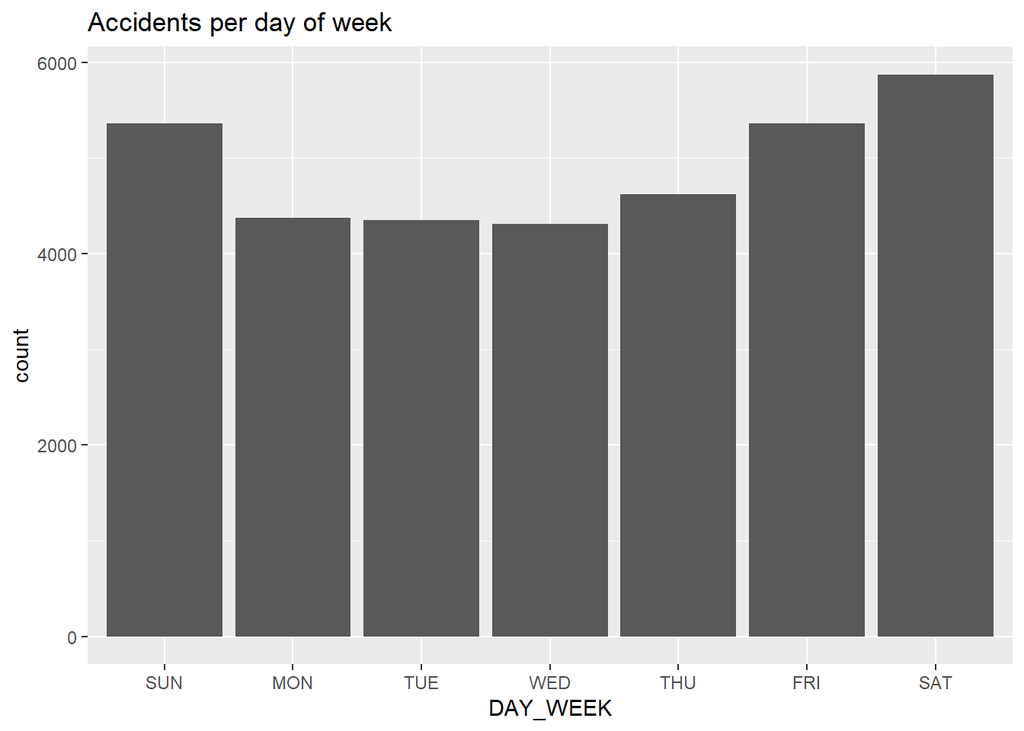

```r
ggplot(acc, aes(x=DAY_WEEK)) + geom_bar() + ggtitle("Accidents per day of week")
```

According to the data, more accidents occur on weekends than on weekdays. The day with the most number of accidents is Saturday.

**What time of the day do accidents happen (use variable HOUR)?**

```r
acc$HOUR[acc$HOUR==99] <- is.na(acc$HOUR)
acc$HOUR <- factor(acc$HOUR)
table(acc$HOUR)
```

```
##
##    0    1    2    3    4    5    6    7    8    9   10   11   12   13   14
## 1583 1177 1241  957  813 1065 1282 1162  945  929 1064 1198 1403 1480 1613
##   15   16   17   18   19   20   21   22   23
## 1760 1770 1916 2000 1880 1930 1880 1683 1516
```

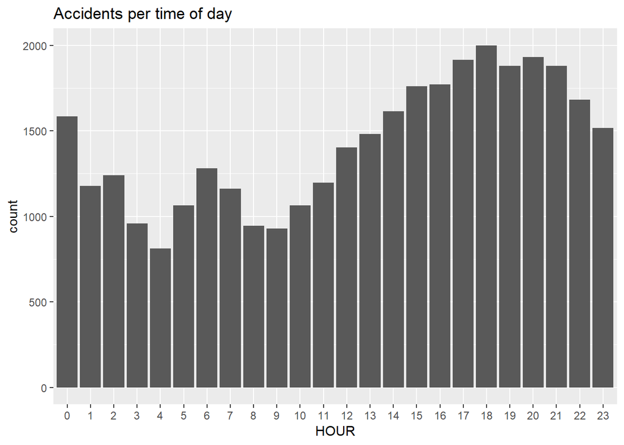

```r
ggplot(acc, aes(x=HOUR)) + geom_bar() + ggtitle("Accidents per time of day")
```

Most accidents occur between 2pm and midnight. The time that the highest number of accidents occurred is 6pm.

**What is the number of accidents with at least one drunk driver (use variable DRUNK_DR)?**

```r
drunk <- acc %>% filter(DRUNK_DR >= 1)
count(drunk)
```

```
## # A tibble: 1 x 1
##       n
##   <int>
## 1  8769
```

The number of accidents involving one or more drunk drivers is 8,769.

# Part 2: Connecting Data

**Load the person table. Identify drivers (PER_TYP == 1, see fars manual) and subset on them.**

```r
drivers <- person %>% filter(PER_TYP==1)
```

**Join accident and driver table (work out which variable(s) to use)**

```r
accAndDrivers <- inner_join(acc, drivers, by="ST_CASE")
```

**Tally the number of accidents by day of the week (DAY_WEEK), hour of the day (HOUR) and gender (SEX). Visualize the results!**

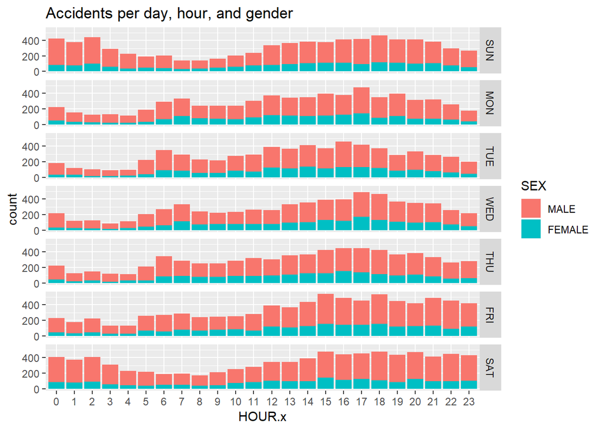

```r
accAndDrivers$SEX[accAndDrivers$SEX %in% c(8,9)] <- NA
accAndDrivers$SEX <- factor(accAndDrivers$SEX)
levels(accAndDrivers$SEX) <- c("MALE", "FEMALE")
accAndDrivers <- filter(accAndDrivers, !is.na(SEX))
ggplot(accAndDrivers, aes(x=HOUR.x, fill=SEX)) + geom_bar(na.rm=TRUE) + facet_grid(DAY_WEEK~.) + ggtitle("Accidents per day, hour, and gender")
```

# Part 3: Connecting Data and Make Maps

**Visualize the number of accidents in each county using a choropleth map. To do this, you need to join the accident data, GLCs, and appropriate map data. Can you find seasonal trends in accident occurrences in different states? Is summer or winter more dangerous? Why?**

```r
glc <- readxl::read_xlsx("FRPP GLC United States.xlsx")
```

```
## * ... and 4 more
```

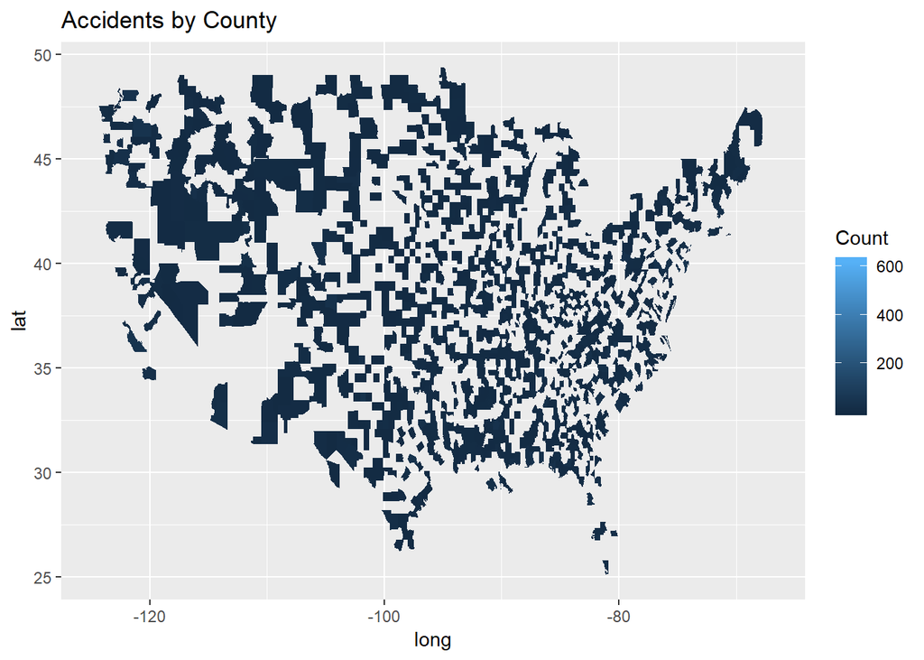

```r
colnames(glc) = glc[1, ]
glc = glc[-1, ]
glc$`County Code` <- as.numeric(glc$`County Code`)
glc$`State Code` <- as.numeric(glc$`State Code`)
glc <- glc %>% select(`State Name`, `State Code`, `County Name`, `County Code`)
glc <- unique(glc)
accGlc <- left_join(acc, glc, by=c("STATE"="State Code", "COUNTY"="County Code")) %>% select("STATE", "ST_CASE", "COUNTY", "MONTH", "State Name", "County Name")
accGlc <- accGlc %>% mutate("STATE_NAME"=tolower(accGlc$`State Name`), "COUNTY_NAME"=tolower(accGlc$`County Name`))
accGlc <- accGlc %>% select(-"State Name", -"County Name")
accGlcState <- accGlc
accGlc <- accGlc %>% group_by(STATE_NAME, COUNTY_NAME) %>% mutate("Count"=n()) %>% select(-"ST_CASE")
accGlc <- unique(accGlc)

counties <- map_data("county")
accGlc.map <- accGlc %>% left_join(counties, by=c("STATE_NAME"="region", "COUNTY_NAME"="subregion"))

accGlc.map %>%
  ggplot(aes(x = long, y = lat, fill=Count)) +
  geom_polygon(aes(group=group)) + ggtitle("Accidents by County")
```

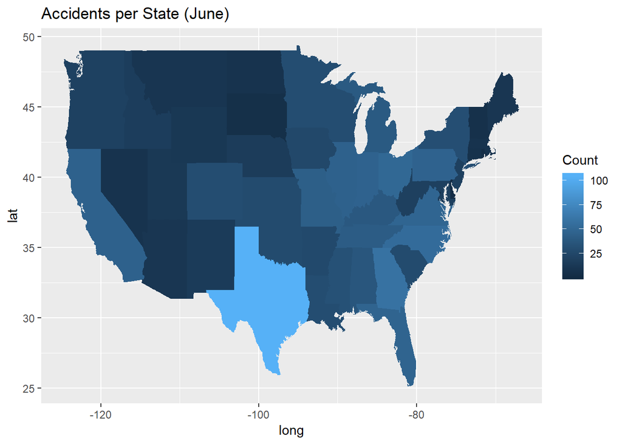

```r
accGlcState <- accGlc %>% group_by(STATE_NAME, MONTH) %>% mutate("Count"=n()) %>% select("MONTH","STATE_NAME","Count")
accGlcState <- unique(accGlcState)

states <- map_data("state")
accGlcState.map <- accGlcState %>% left_join(states, by=c("STATE_NAME"="region"))
accGlcState.map %>% filter(MONTH==6) %>%
  ggplot(aes(x = long, y = lat, fill=Count)) +
  geom_polygon(aes(group=group)) + ggtitle ("Accidents per State (June)")
```

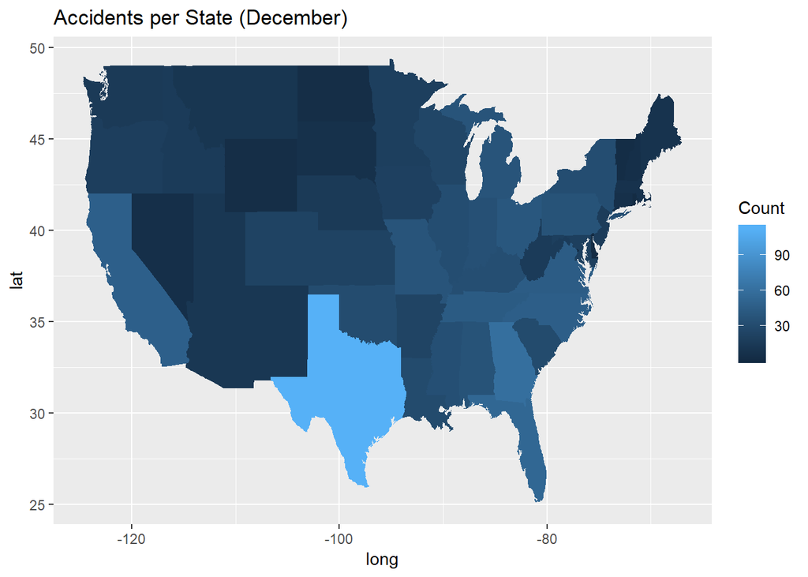

```r
accGlcState.map %>% filter(MONTH==12) %>%
  ggplot(aes(x = long, y = lat, fill=Count)) +
  geom_polygon(aes(group=group)) + ggtitle ("Accidents per State (December)")
```